# RepData_PeerAssessment1_Zach-Arnt

ZBA

2023-09-05

Data downloaded from: https://d396qusza40orc.cloudfront.net/repdata%2Fdata%2Factivity.zip 2023-Sep-05

Description of data from: https://github.com/ZachArnt99/RepData_PeerAssessment1_Zach-Arnt/blob/master/README.md 2023-SEP-05

Description of data: The variables included in this dataset are: steps: Number of steps taking in a 5-minute interval (missing values are coded as NA) date: The date on which the measurement was taken in YYYY-MM-DD format interval: Identifier for the 5-minute interval in which measurement was taken The dataset is stored in a comma-separated-value (CSV) file and there are a total of 17,568 observations in this dataset.

## Analysis

#Load analysis package(s)

```r
library(tidyverse)
```

#Read in the data

```r
activity <- read.csv("activity.csv")
```

#Add columns for use in analysis and plot histogram

```r
activity <- mutate(activity, "intervalID" = 1:17568,
                   "day" = ceiling(intervalID*5/(60*24)),
                   "intervalNUMBER" = rep(1:288,61))
head(activity)
```

```
##   steps       date interval intervalID day intervalNUMBER
## 1    NA 2012-10-01        0          1   1              1
## 2    NA 2012-10-01        5          2   1              2
## 3    NA 2012-10-01       10          3   1              3
## 4    NA 2012-10-01       15          4   1              4
## 5    NA 2012-10-01       20          5   1              5
## 6    NA 2012-10-01       25          6   1              6
```

```r
stepsperday <- aggregate(activity$steps, by = list(day = activity$day),
                         FUN = sum, simplify=TRUE, na.rm=TRUE)
head(stepsperday)
```

```
##   day     x
## 1   1     0
## 2   2   126
## 3   3 11352
## 4   4 12116
## 5   5 13294
## 6   6 15420
```

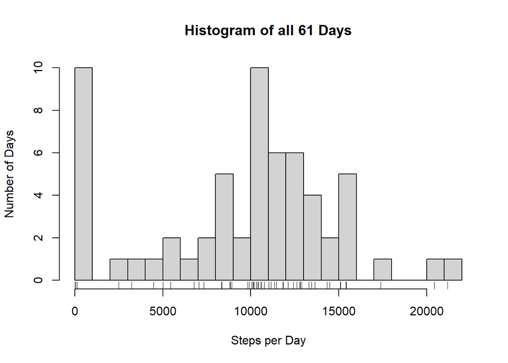

```r
hist(stepsperday$x, breaks=20, main = "Histogram of all 61 Days",
     xlab = "Steps per Day", ylab = "Number of Days")
rug(stepsperday$x)
```

#Average and median steps per day, ignoring missing values:

```r
mean(stepsperday$x)
```

```
## [1] 9354.23
```

```r
median(stepsperday$x)
```

```
## [1] 10395
```

#Store results in a data.frame for later analysis

```r
results <- data.frame("NA Handling" = "ignore", "Mean" = mean(stepsperday$x),
                      "Median" = median(stepsperday$x))
```

#Plot the average number of steps taken during each interval over 61 days.

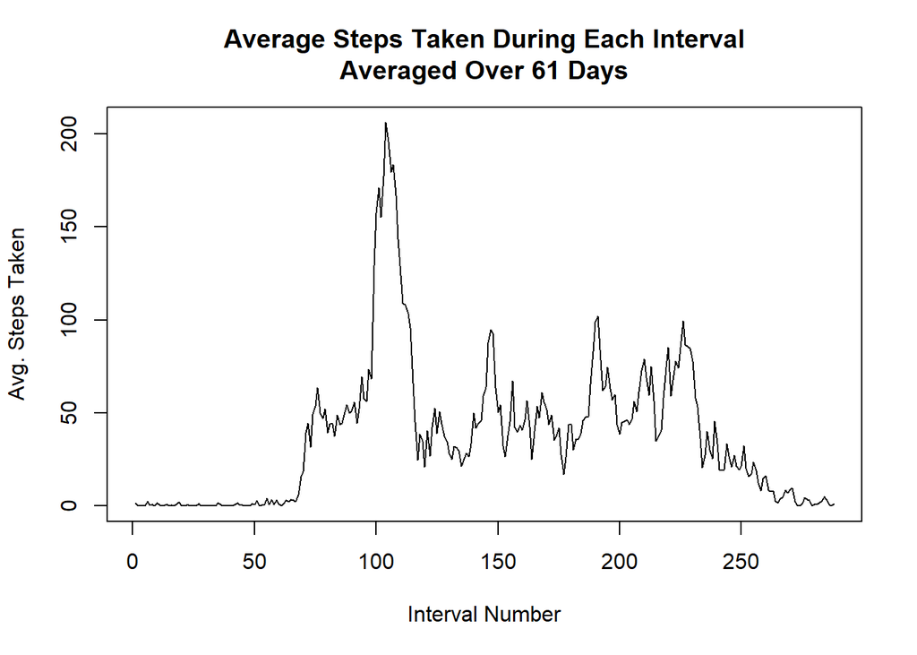

```r
stepsperinterval <- aggregate(activity[, "steps"],
                              by = list(interval = activity$intervalNUMBER),
                              FUN = mean, simplify=TRUE, na.rm=TRUE)

plot(stepsperinterval$interval,stepsperinterval$x,type="l",
     main="Average Steps Taken During Each Interval\nAveraged Over 61 Days",
     xlab= "Interval Number",ylab= "Avg. Steps Taken")
```

#On average, the interval number with the most steps over the 61-day trail is

```r
which(stepsperinterval$x == max(stepsperinterval$x))
```

```
## [1] 104
```

#The total number of rows with NA is

```r
nrow(activity) - nrow(na.omit(activity))
```

```
## [1] 2304
```

#The rows with NAs are:

```r
NArows <- which(is.na(activity$steps))
```

#These correspond to intervalNUMBERs

```r
NAintervals <- activity$intervalNUMBER[NArows]
```

#Method 1: Impute a complete dataset by replacing NAs with averages.

```r
activity1 <- activity
means1 <- stepsperinterval$x
activity1$steps[NArows] <- means1[NAintervals]
```

#Histogram of steps per day in imputed dataset using Method 1 (mean)

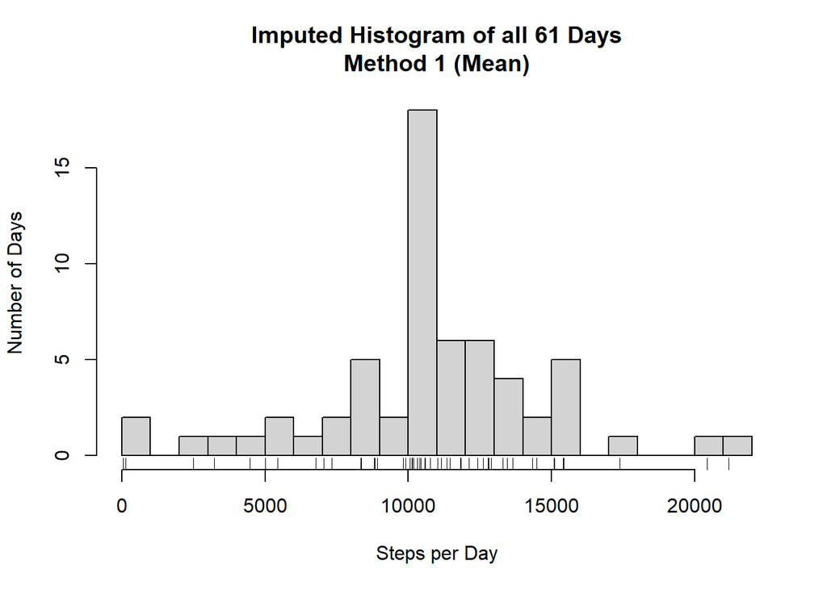

```r
imputed1 <- aggregate(activity1[, "steps"],
                      by = list(day = activity1$day),
                      FUN = sum)
hist(imputed1$x, breaks=20, main = "Imputed Histogram of all 61 Days\nMethod 1 (Mean)",
     xlab = "Steps per Day", ylab = "Number of Days")
rug(imputed1$x)
```

#Average and median steps per day after imputing missing values with Method 1 (mean):

```r
mean(imputed1$x)
```

```
## [1] 10766.19
```

```r
median(imputed1$x)
```

```
## [1] 10766.19
```

#Update results data.frame for later analysis

```r
results[2,1] <- "impute MEAN"
results[2,2] <- mean(imputed1$x)
results[2,3] <- median(imputed1$x)
```

#Method 2: Impute a complete dataset by replacing NAs with medians.

```r
activity2 <- activity
stepsperinterval2 <- aggregate(activity2[, "steps"],
                               by = list(interval = activity2$intervalNUMBER),
                               FUN = median, simplify=TRUE, na.rm=TRUE)
medians <- stepsperinterval2$x
activity2$steps[NArows] <- medians[NAintervals]
```

#Histogram of steps per day in imputed dataset using Method 2 (median)

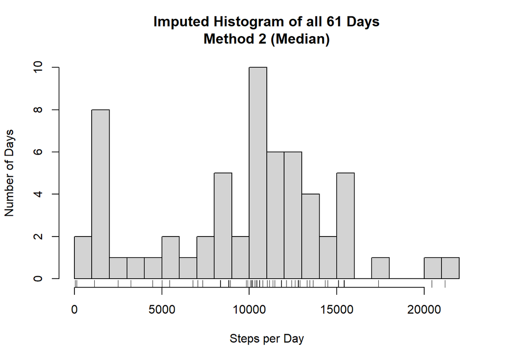

```r
imputed2 <- aggregate(activity2[, "steps"],
                      by = list(day = activity2$day),
                      FUN = sum)

hist(imputed2$x, breaks=20, main = "Imputed Histogram of all 61 Days\nMethod 2 (Median)",
     xlab = "Steps per Day", ylab = "Number of Days")
rug(imputed2$x)
```

#Average and median steps per day after imputing missing values with Method 2 (median):

```r
mean(imputed2$x)
```

```
## [1] 9503.869
```

```r
median(imputed2$x)
```

```
## [1] 10395
```

#Update results data.frame and compare results

```r
results[3,1] <- "impute MEDIAN"
results[3,2] <- mean(imputed2$x)
results[3,3] <- median(imputed2$x)
```

```r
results
```

```
##     NA.Handling      Mean   Median
## 1        ignore  9354.230 10395.00
## 2   impute MEAN 10766.189 10766.19
## 3 impute MEDIAN  9503.869 10395.00
```

#Factorize imputed data set by dayTYPE to compare weekdays and weekends

```r
dayvect <- weekdays(as.Date(activity2$date),abbreviate=TRUE)
wkends <- c("Sat", "Sun")
dayTYPE <- factor((dayvect %in% wkends),
                  levels=c(TRUE,FALSE), labels=c("weekend", "weekday"))

activity2 <- mutate(activity2,dayTYPE=dayTYPE)
head(activity2)
```

```
##   steps       date interval intervalID day intervalNUMBER dayTYPE
## 1     0 2012-10-01        0          1   1              1 weekday
## 2     0 2012-10-01        5          2   1              2 weekday
## 3     0 2012-10-01       10          3   1              3 weekday
## 4     0 2012-10-01       15          4   1              4 weekday
## 5     0 2012-10-01       20          5   1              5 weekday
## 6     0 2012-10-01       25          6   1              6 weekday
```

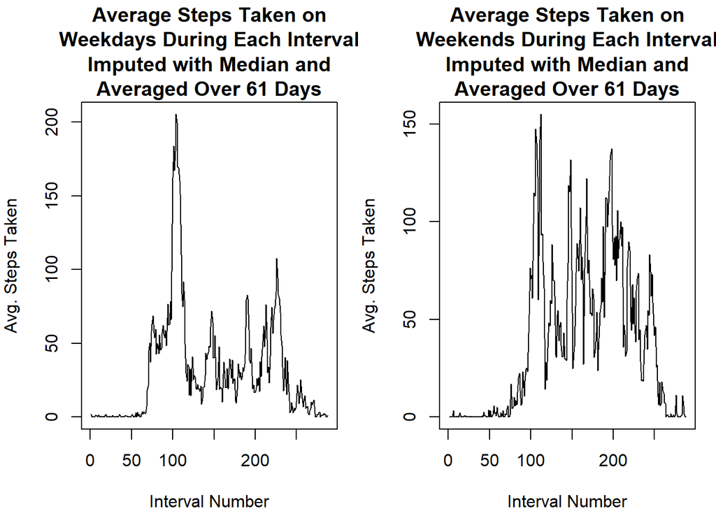

```r
stepsperinterval3 <- split(activity2,f=dayTYPE)

weekdays <- aggregate(stepsperinterval3$weekday[, "steps"],
                      by = list(interval = stepsperinterval3$weekday$intervalNUMBER),
                      FUN = mean)
weekends <- aggregate(stepsperinterval3$weekend[, "steps"],
                      by = list(interval = stepsperinterval3$weekend$intervalNUMBER),
                      FUN = mean)

par(mfrow=c(1,2),mar=c(4,4,5,1))
plot(weekdays$interval,weekdays$x,type="l",
     main="Average Steps Taken on\nWeekdays During Each Interval\nImputed with Median and\nAveraged Over 61 Days",
     xlab= "Interval Number",ylab= "Avg. Steps Taken")
plot(weekends$interval,weekends$x,type="l",
     main="Average Steps Taken on\nWeekends During Each Interval\nImputed with Median and\nAveraged Over 61 Days",
     xlab= "Interval Number",ylab= "Avg. Steps Taken")
```